# Analysis of intraductal lesions from a HER2 Cancer Rainbow mouse model

Liseth Orosco Barrionuevo

2023-11-05

1. Install the packages and load them into the environment

First, I converted an excel file into a csv file to have it ready for upload.

2. Upload and inspect the data set

```r
lesions <- read_csv("Lesions final.csv")
```

```
## ──────────────────────────────────────────────────────── Delimiter: "," chr
## (3): Code, Age, ...13 dbl (10): Number, Total lesions, Type 1, Type 2, Type 3,
## Type 4, Her2bow les...
```

```r
head(lesions)
```

```
## # A tibble: 6 × 13
##   Number Code      `Total lesions` `Type 1` `Type 2` `Type 3` `Type 4` Age
##    <dbl> <chr>               <dbl>    <dbl>    <dbl>    <dbl>    <dbl> <chr>
## 1      1 TG22-0392               4        2        1        1        0 20
## 2      2 TG22-0391               3        2        1        0        0 20
## 3      3 TG22-0375               5        1        2        2        0 20
## 4      4 TG22-0374               6        1        3        2        0 20
## 5      5 TG22-0367               2        0        0        2        0 20
## 6      6 TG22-0077               1        0        1        0        0 17
## # ℹ 5 more variables: `Her2bow lesions` <dbl>, p95 <dbl>, d16 <dbl>, WT <dbl>,
## #   ...13 <chr>
```

```r
#View(lesions)
#spec(lesions)
#show_col_types = TRUE
dim(lesions)
```

```
## [1] 137  13
```

```r
glimpse(lesions)
```

```
## Rows: 137
## Columns: 13
## $ Number            <dbl> 1, 2, 3, 4, 5, 6, 7, 8, 9, 10, 11, 12, 13, 14, 15, 1…
## $ Code              <chr> "TG22-0392", "TG22-0391", "TG22-0375", "TG22-0374", …
## $ `Total lesions`   <dbl> 4, 3, 5, 6, 2, 1, 9, 1, 1, 1, 6, 1, 4, 4, 8, 5, 16, …
## $ `Type 1`          <dbl> 2, 2, 1, 1, 0, 0, 1, 0, 0, 0, 0, 1, 3, 0, 0, 4, 7, 0…
## $ `Type 2`          <dbl> 1, 1, 2, 3, 0, 1, 5, 0, 1, 1, 6, 0, 1, 2, 2, 1, 7, 2…
## $ `Type 3`          <dbl> 1, 0, 2, 2, 2, 0, 3, 0, 0, 0, 0, 0, 0, 2, 6, 0, 2, 1…
## $ `Type 4`          <dbl> 0, 0, 0, 0, 0, 0, 0, 1, 0, 0, 0, 0, 0, 0, 0, 0, 0, 0…
## $ Age               <chr> "20", "20", "20", "20", "20", "17", "10", "17", "19"…
## $ `Her2bow lesions` <dbl> 2, NA, NA, NA, NA, NA, NA, NA, NA, NA, NA, NA, NA, N…
## $ p95               <dbl> 1, NA, NA, NA, NA, NA, NA, NA, NA, NA, NA, NA, NA, N…
## $ d16               <dbl> 1, NA, NA, NA, NA, NA, NA, NA, NA, NA, NA, NA, NA, N…
## $ WT                <dbl> NA, NA, NA, NA, NA, NA, NA, NA, NA, NA, NA, NA, NA, …
## $ ...13             <chr> NA, NA, NA, NA, NA, NA, NA, NA, NA, NA, NA, NA, NA, …
```

3. Determining data type

```r
class(lesions)
```

```
## [1] "spec_tbl_df" "tbl_df"      "tbl"         "data.frame"
```

```r
class(lesions$`Total lesions`)
```

```
## [1] "numeric"
```

```r
class(lesions$`Type 1`)
```

```
## [1] "numeric"
```

```r
class(lesions$`Type 2`)
```

```
## [1] "numeric"
```

```r
class(lesions$`Type 3`)
```

```
## [1] "numeric"
```

```r
class(lesions$`Type 4`)
```

```
## [1] "numeric"
```

```r
class(lesions$Age)
```

```
## [1] "character"
```

```r
class(lesions$`Her2bow lesions`)
```

```
## [1] "numeric"
```

Takeaway: Age is being taken as a character, so when plotting I need to use as.numeric in front of Age.

5. Observing the frequency of samples according to age

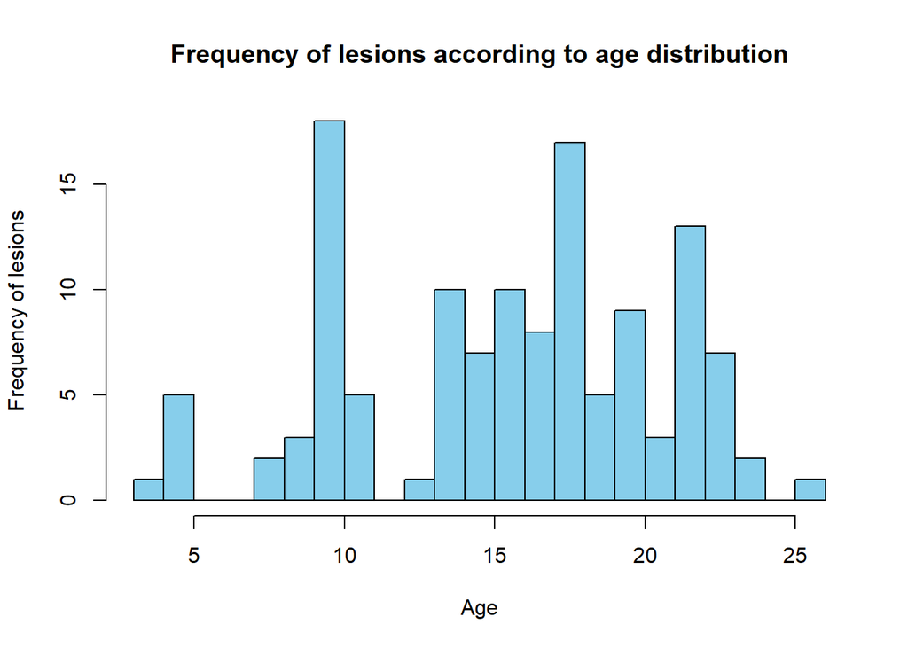

```r
hist(as.numeric(lesions$Age), breaks = 20, freq = TRUE, col = "skyblue",border = "black", xlab = "Age", ylab = "Frequency of lesions", main = "Frequency of lesions according to age distribution")
```

```r
#?hist
```

4. Plotting data

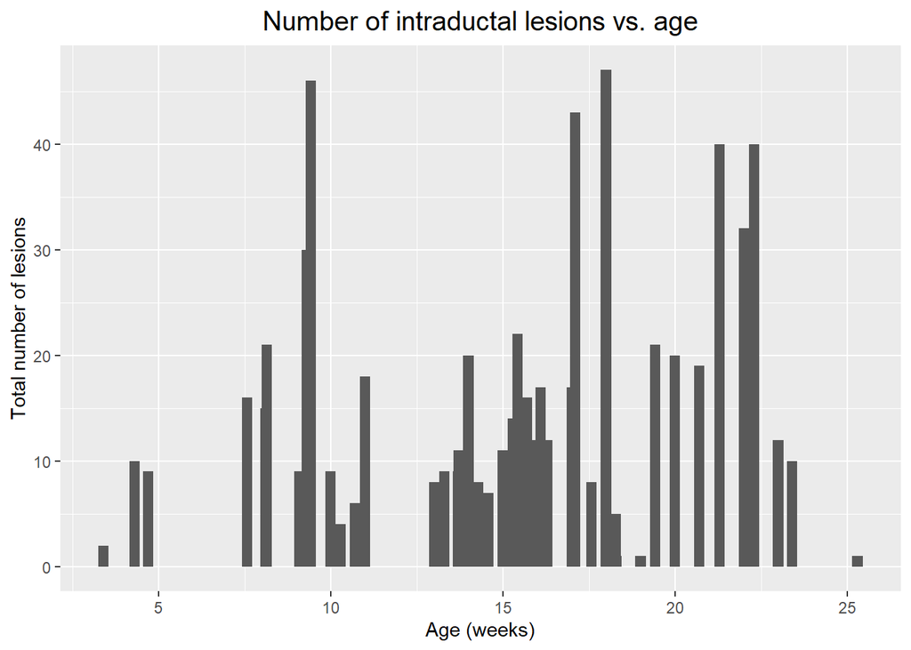

```r
library(ggplot2)

#?geom_bar

# Total lesions vs. age
ggplot(data = lesions, aes(x = as.numeric(lesions$Age), y = lesions$`Total lesions`)) +
  geom_bar(stat = "identity", binwidth = 10,  position = "stack", width = 0.3) +
  xlab('Age (weeks)') +
  ylab('Total number of lesions')+
  ggtitle("Number of intraductal lesions vs. age") +
  theme(plot.title = element_text(size = 15, hjust = 0.5))
```

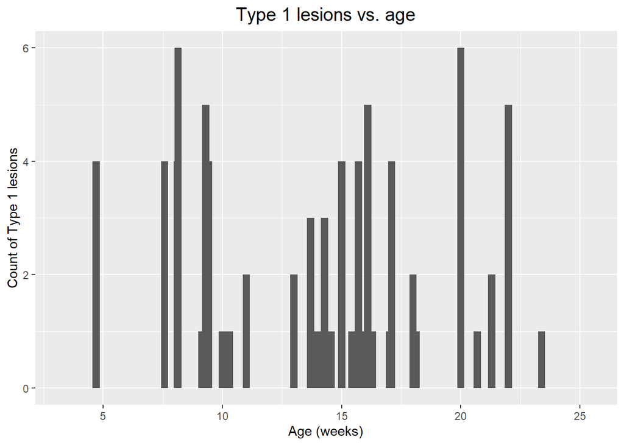

```r
# Type 1 lesions vs. age
ggplot(data = lesions, aes(x = as.numeric(lesions$Age), y = lesions$`Type 1`)) +
  geom_bar(stat = "identity", position = "stack", width = 0.3) +
  xlab('Age (weeks)') +
  ylab('Count of Type 1 lesions')+
  ggtitle("Type 1 lesions vs. age") +
  theme(plot.title = element_text(size = 15, hjust = 0.5))
```

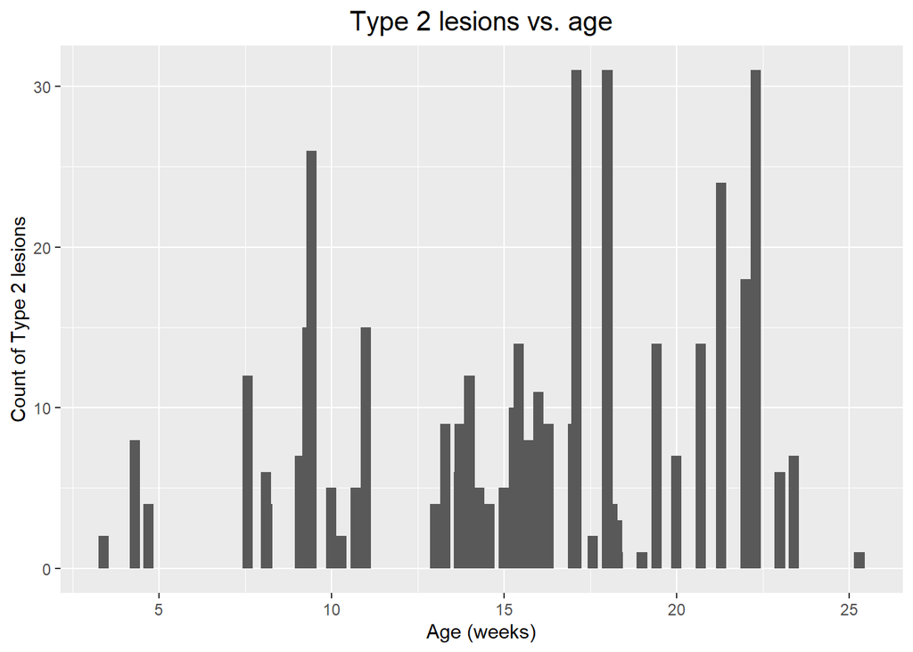

```r
## Type 2 lesions vs. age
ggplot(data = lesions, aes(x = as.numeric(lesions$Age), y = lesions$`Type 2`)) +
  geom_bar(stat = "identity", position = "stack", width = 0.3) +
  xlab('Age (weeks)') +
  ylab('Count of Type 2 lesions')+
  ggtitle("Type 2 lesions vs. age") +
  theme(plot.title = element_text(size = 15, hjust = 0.5))
```

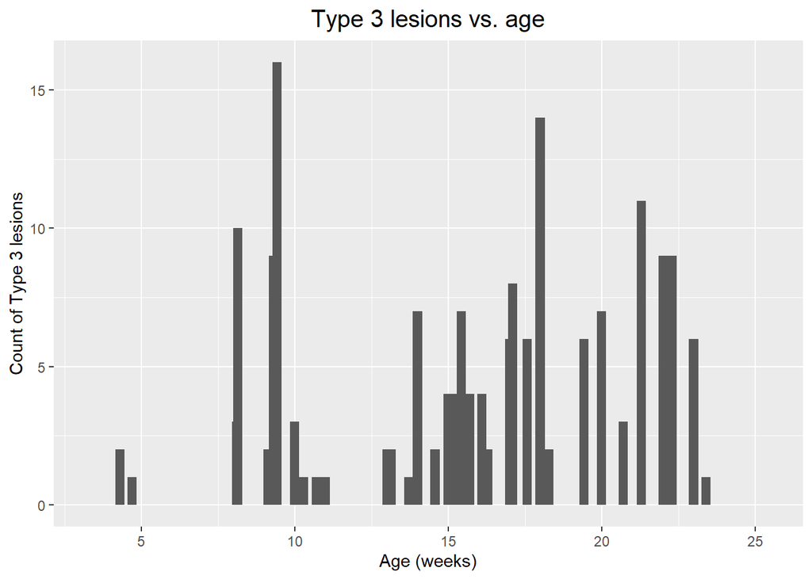

```r
## Type 3 lesions vs. age
ggplot(data = lesions, aes(x = as.numeric(lesions$Age), y = lesions$`Type 3`)) +
  geom_bar(stat = "identity", position = "stack", width = 0.3) +
  xlab('Age (weeks)') +
  ylab('Count of Type 3 lesions')+
  ggtitle("Type 3 lesions vs. age") +
  theme(plot.title = element_text(size = 15, hjust = 0.5))
```

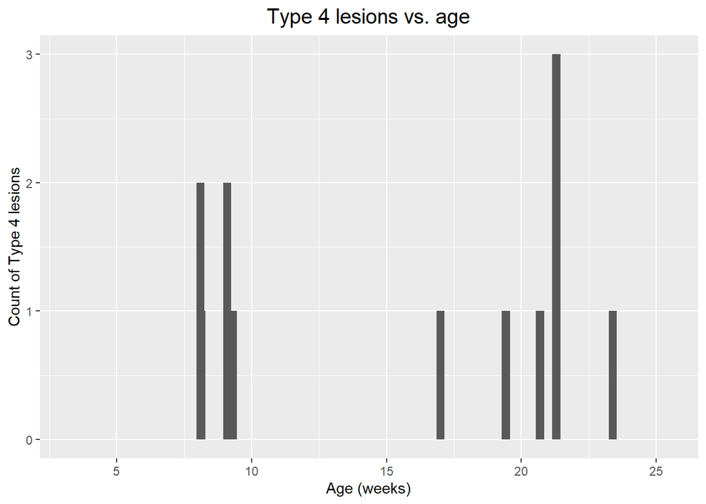

```r
## Type 4 lesions vs. age
ggplot(data = lesions, aes(x = as.numeric(lesions$Age), y = lesions$`Type 4`)) +
  geom_bar(stat = "identity", position = "stack", width = 0.3) +
  xlab('Age (weeks)') +
  ylab('Count of Type 4 lesions')+
  ggtitle("Type 4 lesions vs. age") +
  theme(plot.title = element_text(size = 15, hjust = 0.5))
```

Conclusions:

There is no clear correlation between age and the count of total and the types of intraductal lesions in the mammary gland of Cancer Rainbow mouse model.

Future directions: The screen of quantification should be repeated with an homogeneous sample size of mice per each age and have a constant number of mammary gland sections for analysis.

Challenges: I have encountered many challenges running code in R as this is my first time using ggplot. However, I do think I have progressed during the module and I have tried to overcome the constant errors but not always it was possible without help of someone with experience. It is true that ChatGPT and internet could be helpful, but sometimes the information is outdated for the version of R we are using or simply there is background on the code.